# 03 · What if we checked every licensed location in a year?

**Question.** Instead of choosing a few stores (notebook 02), suppose DOH checked *every* distinct licensed location in the City of Pittsburgh once in a year. (1) How would that work be portioned out? (2) What would it cost, line by line? (3) Is it more effective, in terms of *capture*, than random sampling?

**Context from the Proposed Alternative:**

> We suggest a modified version of the Prize-Collecting Traveling-Salesman Problem (PCTSP) in order to more effectively prioritize Pittsburgh’s nicotine policy checks over random sampling.

**Evidence labels:** *observed* (real records), *simulated* (a synthetic year in which each store sells with the model's probability), *assumed* (a parameter no data identifies: wages, traffic, deterrence). Exact formulas are identities that hold for any probabilities.

**The idea that organizes everything.** A single undercover purchase is a coin flip: store *i* sells to the minor with probability *p_i*. It is not a fixed "violator or compliant" label. So "capture" must be defined before it can be compared:

- *violations detected*: how many sales our checks witness;
- *distinct violators caught*: how many different stores are caught at least once (what enforcement acts on);
- *coverage*: how many stores (and how many of the riskiest) get checked at all;
- *precision*: how well we learn the city's overall violation rate.

Code is in `src/tobacco_inspect/eval/census.py` and `routing/partition.py`.

```python
import warnings

import matplotlib.pyplot as plt
import numpy as np
import pandas as pd

from tobacco_inspect import pipeline
from tobacco_inspect.config import load_config
from tobacco_inspect.eval import census as C
from tobacco_inspect.eval import experiments
from tobacco_inspect.routing import partition as P

warnings.filterwarnings("ignore", category=FutureWarning)
pd.set_option("display.max_columns", 40, "display.width", 170)
cfg = load_config()
params = C.CostParams.from_config(cfg)
DAY = cfg.capacity.daily_budget_minutes
res = pipeline.census(cfg, write=False, n_sims=300)
cand, p, travel = res["cand"], res["p"], res["travel"]
N = len(p)
```

## 1. What is a 'licensed location'?

```python
uni = pipeline.load_universe(cfg)
retail_locs = uni[uni.retail_license].location_key.nunique()
all_locs = uni.location_key.nunique()
rows = [
    ("licenses inside city limits", len(uni)),
    ("distinct locations, all license types", all_locs),
    ("distinct retail-selling locations (the census universe)", retail_locs),
    ("locations with only vending / wholesale / other licenses", all_locs - retail_locs),
]
print(pd.DataFrame(rows, columns=["count of", "n"]).to_string(index=False))
print("\nLicenses by type:"); print(uni.license_type.value_counts().to_string())
cand_obs = cand.fda_observed.mean()
print(f"\nOf the {N} retail locations, {cand_obs:.0%} have at least one FDA record in the data; {int((~cand.fda_observed).sum())} have none")
print(f"Tracts containing a retail location: {cand.tract_geoid.nunique()}")
print(f"Model estimate (population-calibrated): mean p = {p.mean():.3f}; one census is expected to witness about {p.sum():.0f} violations")
```

```
                                                count of   n
                             licenses inside city limits 467
                   distinct locations, all license types 407
 distinct retail-selling locations (the census universe) 345
locations with only vending / wholesale / other licenses  62

Licenses by type:
license_type
Cigarette/OTP Retail        266
OTP Retail                   69
Cigarette Retail             57
Cigarette Vending            42
OTP Vending                  23
Cigarette Wholesaler          3
OTP Wholesaler                3
Cigarette Stamping Agent      2
OTP Itinerant                 2

Of the 345 retail locations, 48% have at least one FDA record in the data; 180 have none
Tracts containing a retail location: 94
Model estimate (population-calibrated): mean p = 0.255; one census is expected to witness about 88 violations
```

**Scope used below:** the 345 distinct *retail* locations, because those are where an under-21 purchaser can buy. Vending-only, wholesale and similar locations are costed as a variant at the end of section 3. The license list is refreshed daily and licenses expire each February, so "a year" means this snapshot plus normal turnover (not modeled).

## 2. Portioning the work

Two separate questions: **where** (which stores share a day) and **when** (which days of the year).

### 2a. Where: cut the city into day-long routes

A team works a day (8 hours: 20 minutes at each store, 15 minutes of paperwork, driving). The stores are cut into routes with a standard "route first, split second" method: draw one good loop through all stores (nearest neighbor then 2-opt), then cut it optimally into pieces that each fit in a day. Drive times come from the OpenStreetMap network times a traffic factor (assumed).

```python
print(res["cost_summary"][["scenario", "stops", "team_days", "team_hours", "drive_hours"]].to_string(index=False))
routes, t, svc = C.build_routes(travel, params, DAY, "base")
mins = np.array([P.route_minutes(r, t, svc) for r in routes])
stops = np.array([len(r) for r in routes])
retries = params.pick("retry_share", "base") * N
onsite = N * params.onsite_minutes
admin = N * params.pick("admin_minutes", "base")
drive = mins.sum() - N * svc[1]
tot = onsite + admin + drive
print(f"\nBase case: {len(routes)} team-days, {stops.min()}-{stops.max()} stores per route (mean {stops.mean():.1f}), longest route {mins.max():.0f} min of {DAY:.0f}")
print(f"Team time split: on site {onsite/tot:.0%}, paperwork {admin/tot:.0%}, driving {drive/tot:.0%} (driving is only {drive/60:.0f} hours in total)")
print(f"Lower bound on team-days from on-site + paperwork time alone: {np.ceil((onsite + admin)/DAY):.0f}")
```

```
scenario  stops  team_days  team_hours  drive_hours
     low    345         24       190.5          8.0
    base    345         28       237.8         13.5
    high    345         37       338.0         21.7

Base case: 28 team-days, 12-13 stores per route (mean 12.3), longest route 478 min of 480
Team time split: on site 54%, paperwork 40%, driving 6% (driving is only 14 hours in total)
Lower bound on team-days from on-site + paperwork time alone: 26
```

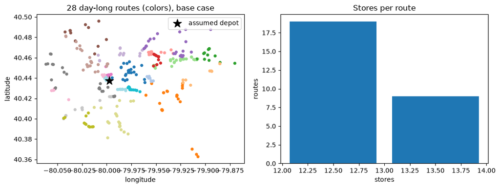

```python
fig, ax = plt.subplots(1, 2, figsize=(11, 4.2))
colors = np.zeros(N)
for r, route in enumerate(routes):
    for node in route:
        colors[node - 1] = r
sc = ax[0].scatter(cand.lon, cand.lat, c=colors, cmap="tab20", s=14)
ax[0].scatter([cfg.raw["solve"]["depot"]["lon"]], [cfg.raw["solve"]["depot"]["lat"]], marker="*", s=180, c="k", label="assumed depot")
ax[0].set_title(f"{len(routes)} day-long routes (colors), base case"); ax[0].legend(); ax[0].set_xlabel("longitude"); ax[0].set_ylabel("latitude")
ax[1].hist(stops, bins=range(stops.min(), stops.max() + 2), rwidth=0.85)
ax[1].set_title("Stores per route"); ax[1].set_xlabel("stores"); ax[1].set_ylabel("routes")
plt.tight_layout(); plt.show()
```

**How good is the heuristic?** On random 9-store subsets of the routes the heuristic tour is compared with the *exact* optimal tour (Held-Karp dynamic programming).

```python
gaps = P.heuristic_gap(routes, t, svc, size=9, trials=30)
print(f"Heuristic vs exact on {len(gaps)} subsets: mean excess {np.mean(gaps):.2%}, worst {np.max(gaps):.2%}")
```

```
Heuristic vs exact on 30 subsets: mean excess 0.05%, worst 0.37%
```

### 2b. When: four ways to place the routes on a calendar

All use random placement so no neighborhood learns its day in advance.

- **A. Summer block**: all routes between July 6 and August 21 (the window Synar uses, when youth purchasers are available).
- **B. Quarters**: a quarter of the routes in each quarter, random order.
- **C. Months**: a twelfth each month.
- **D. Risk-staged**: the riskiest routes in the first quarter, the least risky in the last, random inside each quarter.

```python
rows = []
for plan, name in {"A": "A summer block", "B": "B quarters", "C": "C months", "D": "D risk-staged"}.items():
    s = C.calendar_summary(res["calendars"][plan])
    rows.append({"plan": name, **s})
print(pd.DataFrame(rows).to_string(index=False))
print(f"\nWith {cfg.capacity.teams} teams, {len(routes)} team-days fit in about {int(np.ceil(len(routes)/(5*cfg.capacity.teams)))} working weeks of one block.")
sweep = pd.DataFrame([{"teams": k, "working_weeks_for_a_block": int(np.ceil(len(routes) / (5 * k)))} for k in cfg.raw["census"]["teams_options"]])
print(sweep.to_string(index=False))
```

```
          plan  first_day   last_day  calendar_weeks  busiest_month_routes  months_covered
A summer block 2027-07-06 2027-08-20               8                    18               2
    B quarters 2027-01-14 2027-12-30              51                     4              12
      C months 2027-01-06 2027-12-09              50                     3              12
 D risk-staged 2027-01-11 2027-12-14              50                     5              12

With 2 teams, 28 team-days fit in about 3 working weeks of one block.
 teams  working_weeks_for_a_block
     1                          6
     2                          3
     4                          2
     8                          1
```

**What risk-staging costs.** Putting the riskiest stores first means routing each risk tier separately, so stops are more scattered:

```python
print(C.risk_staged_cost(travel, params, p, DAY).to_string(index=False))
```

```
                                  plan  team_days  total_minutes  extra_team_days_vs_geographic  extra_minutes_vs_geographic
               geographic (all stores)         28          12886                              0                            0
risk tiers x4 (each routed separately)         32          13273                              4                          387
```

**Does the order matter?** Only if a check changes a store's behavior for a while afterwards. Under an **assumed** three-month window the *total* protection over a repeating year is identical for every calendar; what differs is the profile through the year:

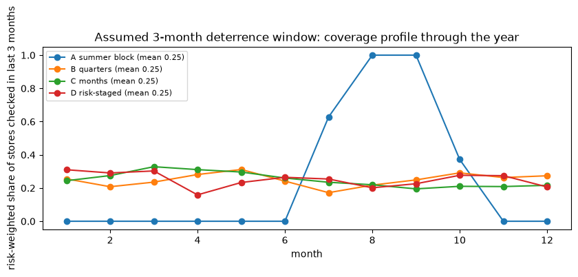

```python
months = np.arange(1, 13)
fig, ax = plt.subplots(figsize=(8.5, 3.6))
for plan, label in {"A": "A summer block", "B": "B quarters", "C": "C months", "D": "D risk-staged"}.items():
    cm = C.store_check_months(routes, res["calendars"][plan], N)
    prof = C.monthly_protection(cm, p, memory_months=3)
    ax.plot(months, prof, marker="o", label=f"{label} (mean {prof.mean():.2f})")
ax.set_xlabel("month"); ax.set_ylabel("risk-weighted share of stores checked in last 3 months")
ax.set_title("Assumed 3-month deterrence window: coverage profile through the year"); ax.legend(fontsize=8)
plt.tight_layout(); plt.show()
```

**Reading it.** A summer block is cheapest to organize and mimics Synar, but leaves winter and spring with no recently-checked stores (under the assumed window). Spreading the routes across the year keeps a steady presence. The window length itself is **assumed**; if checks have no lasting effect, the calendar does not matter.

## 3. The expense breakdown

Two independent views, because neither is certain:

- **Bottom-up (marginal)**: price the actual routes: supervisor and purchaser hours, mileage, retries, data handling, one-time training, overhead.
- **Top-down (fully loaded)**: DOH's award divided by checks: $116 if the funded 10,000 checks happen, about $400 if only the roughly 2,900 published checks do.

Sourced inputs: IRS 2026 mileage rate (72.5 cents Jan-Jun, 76 cents Jul-Dec); a contractor posting offers $15 an hour to under-21 purchasers; BLS reports a mean of $35.28 an hour for Pittsburgh compliance officers (used as the supervisor proxy). Everything else in the table is **assumed** and varied.

```python
comp = res["components"].pivot_table(index="component", columns="scenario", values="dollars", sort=False)[["low", "base", "high"]]
comp.loc["TOTAL"] = comp.sum()
print(comp.round(0).astype(int).to_string())
cs = res["cost_summary"].set_index("scenario")
print("\nPer check (bottom-up):", {k: f"${v:,.0f}" for k, v in cs.dollars_per_check.items()})
td = C.top_down_cost(N, params)
print(f"Top-down for {N} checks: ${td['low']:,.0f} (at $116) to ${td['high']:,.0f} (at $400)")
```

```
scenario                                       low   base   high
component
labor (supervisor + purchaser, with fringe)  10240  16139  32954
mileage                                        324    806   1866
data handling and QA                           724   1898   4140
training and commissioning (one-time)            0   2000   5000
overhead (indirect / fixed fee)               1693   6253  21980
TOTAL                                        12982  27096  65940

Per check (bottom-up): {'low': '$38', 'base': '$78', 'high': '$191'}
Top-down for 345 checks: $40,020 (at $116) to $138,000 (at $400)
```

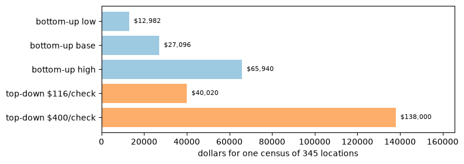

```python
fig, ax = plt.subplots(figsize=(8, 2.9))
bars = [("bottom-up low", cs.loc["low", "total_dollars"]), ("bottom-up base", cs.loc["base", "total_dollars"]),
        ("bottom-up high", cs.loc["high", "total_dollars"]), ("top-down $116/check", td["low"]), ("top-down $400/check", td["high"])]
ax.barh([b[0] for b in bars], [b[1] for b in bars], color=["#9ecae1"] * 3 + ["#fdae6b"] * 2)
for i, b in enumerate(bars):
    ax.text(b[1], i, f"  ${b[1]:,.0f}", va="center", fontsize=8)
ax.set_xlabel("dollars for one census of %d locations" % N); ax.invert_yaxis(); ax.set_xlim(0, td["high"] * 1.2)
plt.tight_layout(); plt.show()
```

**Why the two views differ.** Bottom-up prices only the extra work in a dense city (little driving: the stores are close together). The award per check also pays for statewide travel, management, reporting and contractor margin. Treat bottom-up as the *marginal* cost of adding this work to an existing program and top-down as the *full-cost* price if a new program had to carry it.

**What drives the bottom-up total** (one parameter at a time, others at base):

```python
sens = C.cost_sensitivity(travel, params, DAY)
sens["low_to_high"] = sens.apply(lambda r: f"{r.low_value:g} -> {r.high_value:g}", axis=1)
print(sens[["parameter", "low_to_high", "total_at_low", "total_at_high", "swing"]].round(0).to_string(index=False))
```

```
              parameter   low_to_high  total_at_low  total_at_high  swing
          admin_minutes      10 -> 25         24085          33111   9026
         overhead_share   0.15 -> 0.5         23970          31265   7295
        supervisor_wage      28 -> 45         24058          31152   7094
         training_fixed     0 -> 5000         24496          30996   6500
         data_per_check       2 -> 10         25616          29563   3947
                 fringe   1.25 -> 1.5         25542          29427   3885
            retry_share   0.05 -> 0.2         25938          29412   3474
         purchaser_wage      15 -> 20         27096          29183   2087
commute_miles_per_route      10 -> 50         26681          27788   1107
           drive_factor        1 -> 2         26553          27609   1056
           mileage_rate 0.725 -> 0.76         27048          27096     48
```

**The follow-up layer.** FDA practice re-checks violators; a census would find many, and re-checking them adds cost.

```python
rows = []
for sc in ["low", "base", "high"]:
    rate = params.pick("followup_rate", sc)
    extra, repeats = C.followup_repeats(p, rate)
    per = cs.loc[sc, "dollars_per_check"]
    rows.append({"follow-up rate": rate, "extra checks": round(extra), "repeat violations caught": round(repeats, 1),
                 "extra cost at bottom-up base per check": round(extra * cs.loc["base", "dollars_per_check"]),
                 "extra cost at $116": round(extra * 116), "extra cost at $400": round(extra * 400)})
print(pd.DataFrame(rows).to_string(index=False))
```

```
 follow-up rate  extra checks  repeat violations caught  extra cost at bottom-up base per check  extra cost at $116  extra cost at $400
           0.58            51                      15.5                                    4005                5918               20405
           0.73            64                      19.5                                    5040                7448               25683
           0.88            77                      23.6                                    6076                8978               30960
```

**Context and scale.**

```python
fy = pd.read_csv(cfg.path("interim") / "oce_pa_by_fiscal_year.csv")
recent = fy[fy.fy.between(2022, 2025)]
city_year = recent.city_up_checks.mean(); pa_year = recent.up_checks.mean()
award = 1_159_731
print(f"Recent city volume: about {city_year:.0f} undercover checks a year; a census is {N / city_year:.1f} times that")
print(f"A census is {N / pa_year:.0%} of Pennsylvania's recent published undercover checks ({pa_year:,.0f} a year)")
print(f"As a share of the latest annual DOH award (${award:,}): bottom-up base {cs.loc['base','total_dollars']/award:.1%}; top-down {td['low']/award:.1%} to {td['high']/award:.1%}")
print(f"Current volume at the same per-check prices: ${city_year * 116:,.0f} to ${city_year * 400:,.0f} a year")
inst_all = pipeline.build_instance(cfg, retail_only=False)
ct_all = C.cost_table(inst_all["travel"], params, DAY)
print(f"\nVariant: every distinct licensed location, any license type ({len(inst_all['cand'])} locations):")
print(ct_all.to_string(index=False))
```

```
Recent city volume: about 44 undercover checks a year; a census is 7.9 times that
A census is 13% of Pennsylvania's recent published undercover checks (2,635 a year)
As a share of the latest annual DOH award ($1,159,731): bottom-up base 2.3%; top-down 3.5% to 11.9%
Current volume at the same per-check prices: $5,046 to $17,400 a year
```

```
Variant: every distinct licensed location, any license type (407 locations):
scenario  stops  team_days  team_hours  drive_hours  total_dollars  dollars_per_check
     low    407         28       224.5          9.2          15294               37.6
    base    407         33       280.2         15.7          31465               77.3
    high    407         44       397.4         24.3          76236              187.3
```

## 4. Is a census more effective than random sampling?

**First, the exact definitions.** With *n* checks and store probabilities p_i (mean p-bar):

| Policy | Violations detected (expected) | Distinct violators caught | Stores covered |
| --- | --- | --- | --- |
| Census (every store once) | sum of p_i | sum of p_i | 100% |
| Simple random sample, no repeats | n x p-bar | (n/N) x sum of p_i | n/N |
| Absolute random draws (a store can be picked again) | n x p-bar | sum of 1 - (1 - p_i/N)^n | 1 - (1 - 1/N)^n |
| Model-targeted top n | sum of the top n p_i (if the model is right) | same | n/N, but the riskiest first |

So at the same number of checks, **a census detects the same number of violations per check as any random scheme**. Differences appear in *who* is covered.

```python
cap = res["capture"]
show = cap[cap.budget_share_of_N.isin([0.25, 0.5, 1.0])].copy()
show = show[["policy", "budget_checks", "distinct_exact", "distinct_sim", "coverage_exact", "top_decile_covered", "distinct_if_lift"]]
print(show.round(2).to_string(index=False))
print("\n(distinct_sim is a 300-run Monte Carlo of the exact column; distinct_if_lift replaces the model's own p with the observed replay lift of about 1.5x for the targeted row)")
```

```
    policy  budget_checks  distinct_exact  distinct_sim  coverage_exact  top_decile_covered  distinct_if_lift
       srs             86           21.92         21.71            0.25                0.25             21.92
       iid             86           21.12         21.31            0.22                0.22             21.12
stratified             86           21.92         22.16            0.25                0.25             21.92
  targeted             86           34.69         34.49            0.25                1.00             32.89
       srs            172           43.85         43.33            0.50                0.50             43.85
       iid            172           40.72         40.87            0.39                0.39             40.72
stratified            172           43.85         43.10            0.50                0.50             43.85
  targeted            172           59.10         58.68            0.50                1.00             59.10
       srs            345           87.95         88.27            1.00                1.00             87.95
       iid            345           75.97         75.88            0.63                0.63             75.97
stratified            345           87.95         88.76            1.00                1.00             87.95
  targeted            345           87.95         87.74            1.00                1.00             87.95

(distinct_sim is a 300-run Monte Carlo of the exact column; distinct_if_lift replaces the model's own p with the observed replay lift of about 1.5x for the targeted row)
```

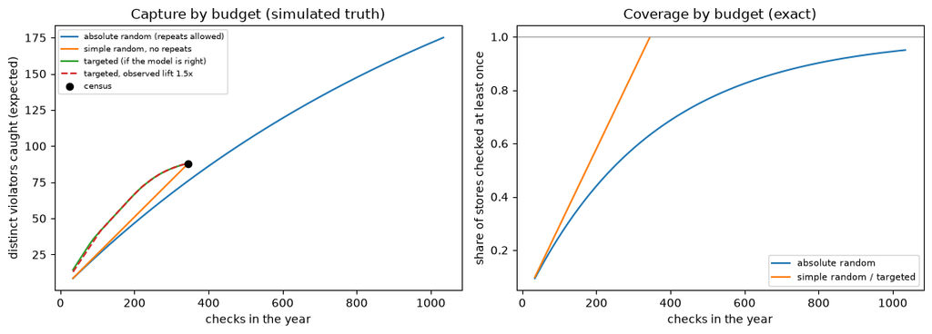

```python
budgets = np.arange(int(0.1 * N), int(3 * N) + 1, 5)
fig, ax = plt.subplots(1, 2, figsize=(11.5, 4.2))
ax[0].plot(budgets, [C.distinct_iid(p, n) for n in budgets], label="absolute random (repeats allowed)")
nn = budgets[budgets <= N]
ax[0].plot(nn, [C.distinct_srs(p, n) for n in nn], label="simple random, no repeats")
ax[0].plot(nn, [C.distinct_targeted(p, n) for n in nn], label="targeted (if the model is right)")
ax[0].plot(nn, [min(C.distinct_targeted(p, n), 1.5 * n * p.mean()) for n in nn], ls="--", label="targeted, observed lift 1.5x")
ax[0].scatter([N], [C.distinct_census(p)], c="k", zorder=5, label="census")
ax[0].set_xlabel("checks in the year"); ax[0].set_ylabel("distinct violators caught (expected)"); ax[0].legend(fontsize=7); ax[0].set_title("Capture by budget (simulated truth)")
ax[1].plot(budgets, [C.coverage_iid(N, n) for n in budgets], label="absolute random")
ax[1].plot(nn, nn / N, label="simple random / targeted")
ax[1].axhline(1, c="grey", lw=0.6); ax[1].set_xlabel("checks in the year"); ax[1].set_ylabel("share of stores checked at least once"); ax[1].legend(fontsize=8)
ax[1].set_title("Coverage by budget (exact)")
plt.tight_layout(); plt.show()
```

```python
cen, iid = C.distinct_census(p), C.distinct_iid(p, N)
print(f"At the census budget ({N} checks): census catches {cen:.1f} distinct violators; absolute random catches {iid:.1f} ({iid/cen-1:+.0%}) and covers {C.coverage_iid(N, N):.0%} of stores")
print(f"Random draws needed to catch as many distinct violators as one census: {C.iid_budget_for_distinct(p, cen)/N:.2f} x N = {C.iid_budget_for_distinct(p, cen):.0f} checks")
for q in (0.9, 0.95, 0.99):
    print(f"Random draws needed to cover {q:.0%} of stores: {C.iid_budget_for_coverage(N, q)/N:.2f} x N = {C.iid_budget_for_coverage(N, q):.0f} checks")
dec = max(1, N // 10)
print(f"\nRiskiest 10% of stores ({dec}): census covers all; a {N//4}-check simple random sample covers {N//4/N:.0%}; targeted covers 100% of them with {dec} checks")
```

```
At the census budget (345 checks): census catches 88.0 distinct violators; absolute random catches 76.0 (-14%) and covers 63% of stores
Random draws needed to catch as many distinct violators as one census: 1.19 x N = 411 checks
Random draws needed to cover 90% of stores: 2.30 x N = 794 checks
Random draws needed to cover 95% of stores: 3.00 x N = 1034 checks
Random draws needed to cover 99% of stores: 4.61 x N = 1589 checks

Riskiest 10% of stores (34): census covers all; a 86-check simple random sample covers 25%; targeted covers 100% of them with 34 checks
```

### Precision and the value of unbiased labels

```python
se_c, se_n100, se_nN = C.se_rate_census(p), C.se_rate_sample(p, 100), C.se_rate_sample(p, N)
print(f"Standard error of the observed city violation rate: census {se_c:.1%}; {N} random checks {se_nN:.1%}; Synar-sized sample (n=100) {se_n100:.1%}")
print(f"95% interval half-width: census +/-{1.96*se_c:.1%}, n=100 +/-{1.96*se_n100:.1%}")
pw = experiments.power_table(0.26, N)
print("\nFor reference, years of random-arm data needed at the city's current volume were 8.5 (rate) and 23 (lift) at a 20% share; a census delivers both in one year.")
print(f"\nStores with no FDA record today: {int((~cand.fda_observed).sum())} of {N} ({(~cand.fda_observed).mean():.0%}). A census gives every one of them a first, unselected label,")
print("which is the fix for the selection bias that limits the risk model (a census is an unbiased training sample of the whole city, once).")
```

```
Standard error of the observed city violation rate: census 2.3%; 345 random checks 2.3%; Synar-sized sample (n=100) 4.4%
95% interval half-width: census +/-4.4%, n=100 +/-8.5%

For reference, years of random-arm data needed at the city's current volume were 8.5 (rate) and 23 (lift) at a 20% share; a census delivers both in one year.

Stores with no FDA record today: 180 of 345 (52%). A census gives every one of them a first, unselected label,
which is the fix for the selection bias that limits the risk model (a census is an unbiased training sample of the whole city, once).
```

### Capture per dollar

```python
rows = []
base_pc, lo_pc, hi_pc = cs.loc["base", "dollars_per_check"], 116, 400
for label, n, distinct in [
    ("census", N, C.distinct_census(p)),
    ("targeted, observed lift 1.5x", N // 4, min(C.distinct_targeted(p, N // 4), 1.5 * (N // 4) * p.mean())),
    ("targeted, model's own p (optimistic)", N // 4, C.distinct_targeted(p, N // 4)),
    ("simple random, same budget as targeted", N // 4, C.distinct_srs(p, N // 4)),
    ("absolute random, same budget as census", N, C.distinct_iid(p, N)),
]:
    rows.append({"policy": label, "checks": n, "distinct violators": round(distinct, 1),
                 "checks per violator": round(n / distinct, 2),
                 "$ per violator (bottom-up base)": round(n * base_pc / distinct),
                 "$ per violator ($116)": round(n * lo_pc / distinct), "$ per violator ($400)": round(n * hi_pc / distinct)})
print(pd.DataFrame(rows).to_string(index=False))
extra_checks = N - N // 4
extra_v = C.distinct_census(p) - min(C.distinct_targeted(p, N // 4), 1.5 * (N // 4) * p.mean())
print(f"\nGoing from a targeted quarter-sized program to a full census adds {extra_checks} checks to catch {extra_v:.0f} more distinct violators: {extra_checks/extra_v:.1f} extra checks per extra violator,")
print(f"about ${extra_checks*base_pc/extra_v:,.0f} (bottom-up base) to ${extra_checks*hi_pc/extra_v:,.0f} ($400/check) each")
```

```
                                policy  checks  distinct violators  checks per violator  $ per violator (bottom-up base)  $ per violator ($116)  $ per violator ($400)
                                census     345                88.0                 3.92                              308                    455                   1569
          targeted, observed lift 1.5x      86                32.9                 2.61                              205                    303                   1046
  targeted, model's own p (optimistic)      86                34.7                 2.48                              195                    288                    992
simple random, same budget as targeted      86                21.9                 3.92                              308                    455                   1569
absolute random, same budget as census     345                76.0                 4.54                              356                    527                   1816

Going from a targeted quarter-sized program to a full census adds 259 checks to catch 55 more distinct violators: 4.7 extra checks per extra violator,
about $369 (bottom-up base) to $1,881 ($400/check) each
```

### Doing more than one pass

```python
two = C.distinct_two_pass(p)
extra_f, repeats = C.followup_repeats(p, params.pick("followup_rate", "base"))
print(f"Census + follow-up of violators (rate {params.pick('followup_rate','base'):.0%}): {extra_f:.0f} extra checks, {repeats:.1f} repeat violations caught (these trigger FDA's escalating penalties)")
print(f"Two full passes: {2*N} checks, {two:.1f} distinct violators vs {cen:.1f} for one pass (+{two-cen:.1f}) for {N} extra checks: {N/(two-cen):.0f} checks per extra violator")
```

```
Census + follow-up of violators (rate 73%): 64 extra checks, 19.5 repeat violations caught (these trigger FDA's escalating penalties)
Two full passes: 690 checks, 149.1 distinct violators vs 88.0 for one pass (+61.2) for 345 extra checks: 6 checks per extra violator
```

## 5. Verdict, limits and what to decide

[output not shown]

**Hybrid worth testing:** a one-time census (or a stratified half-census) to learn the true base rate and label every store, then return to a targeted, randomized list using the unbiased labels.

**Limits.** The capture numbers use the model's own probabilities (population-calibrated to Synar's 26% Allegheny rate, interval 17-35%); the identities hold for any probabilities, the levels do not. Wages, traffic, paperwork time, retry share, overhead, training and the deterrence window are assumptions. Youth-purchaser availability (school calendars, legal limits) is not modeled. The FDA contract sets targets with the contractor, so a city census may need FDA approval or separate funding.

**Human checkpoints.** (1) Agree the unit (345 retail locations; 407 with every license type). (2) Replace the assumed cost inputs with DOH or contractor figures. (3) Confirm the funding and authority path. (4) Decide whether coverage, measurement and unbiased labels are worth the added cost. (5) Confirm each figure's label before reuse.